# R Notebook

```r
library(data.table)
library(rio)
library(ggpubr)
library(rstatix)
library(plotrix)
library(scales)
```

```r
dat_train = rio::import('data/train_sample.dta',setclass = 'data.table')
dat_train[, type :="train"]
dat_test = rio::import('data/test_sample.dta',setclass = "data.table")
dat_test[, type:='test']
dat = rbindlist(list(dat_train, dat_test),fill = TRUE, use.names = TRUE)
```

```r
get_rate_per_group = function(col_name,  col_type="type"){
  dat_ = dat[,.(count=.N), by=c(col_name, col_type)]
  dat_ = dat_[, rate:= count/sum(count), by=c(col_type)]
  dat_ = dcast(dat_, paste0(col_name, '~', col_type),value.var = "rate")
  dat_[, diff := train-test]
  return(dat_)
  }
```

# 1 Goal

The goal is to predict `incwage` (in integer), and the evaluation metric is mean square error.

# 2 Distribution on Income

The average income is 54,278, but median is 38,000. The top 10% quantile is 110,000, and top 5% quantile is 150,000. However, bottom 5% is 2,100, and bottom 10% is 5000.

We expect large gap between observations. The raw income distribution is skewed.

```r
summary(dat_train$incwage)
```

```
##    Min. 1st Qu.  Median    Mean 3rd Qu.    Max.
##       4   17000   38000   54278   67000  717000
```

```r
quant_vars = quantile(dat_train$incwage, probs = c(0.05, 0.1, 0.5, 0.9,0.95))
print("Quantils: ")
```

```
## [1] "Quantils: "
```

```r
print(quant_vars)
```

```
##     5%    10%    50%    90%    95%
##   2100   5000  38000 110000 150000
```

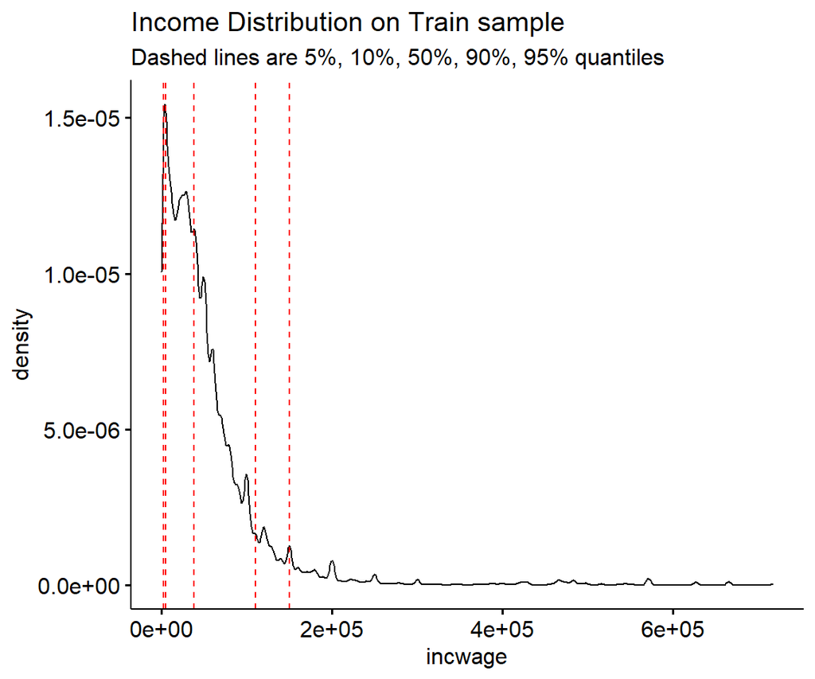

```r
ggdensity(dat_train,
          x="incwage",
          title="Income Distribution on Train sample",
          subtitle="Dashed lines are 5%, 10%, 50%, 90%, 95% quantiles")  +
  geom_vline(xintercept = as.numeric(quant_vars),
             color="red", linetype="dashed")
```

But the log(income) is approximately normal.

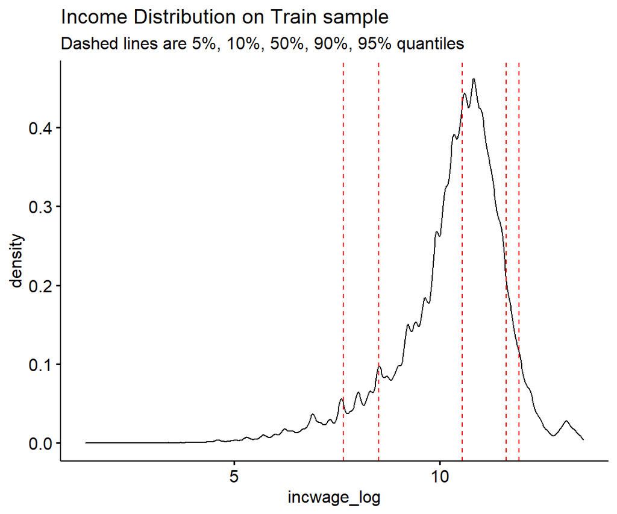

```r
dat_train[, incwage_log := log(incwage)]
ggdensity(dat_train,
          x="incwage_log",
          title="Income Distribution on Train sample",
          subtitle="Dashed lines are 5%, 10%, 50%, 90%, 95% quantiles")  +
  geom_vline(xintercept = as.numeric(log(quant_vars)),
             color="red", linetype="dashed")
```

# 3 Distribution on Independent Variables

We combine train and test to see whether there are significant difference. The ratio of each type are almost the same in train and test group.

## 3.1 Categorical Variables

All variables are pre-encoded into numbers.

If we use embedding for each category variables, `degfield` shall get special attention, followed by `educ` as they seem to have high predictive power. `language` and `bpl` may need to consider sparse setting as the majority speakers are English speakers born within the U.S., but they have diverse income.

```
## ### sex
## [1] "Number of unique values for sex: 2"
## [1] "Summary on Train/Test rate for group count"
##      Min.   1st Qu.    Median      Mean   3rd Qu.      Max.
## -1.35e-05 -6.75e-06  0.00e+00  0.00e+00  6.75e-06  1.35e-05
```

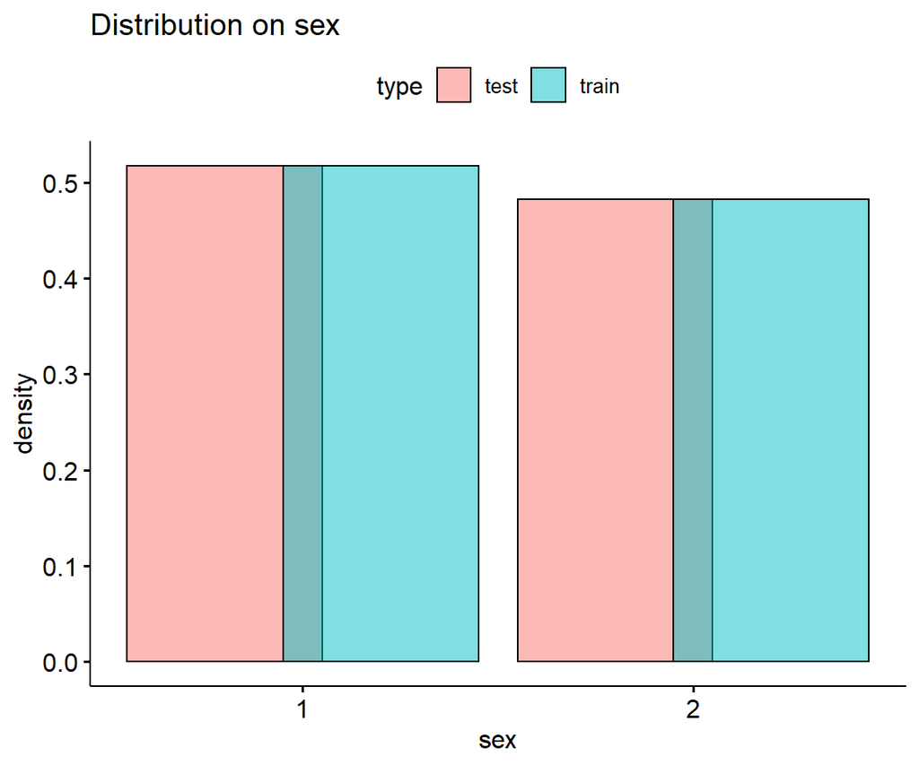

```
## Train Data: check Incwage ~ sex
```

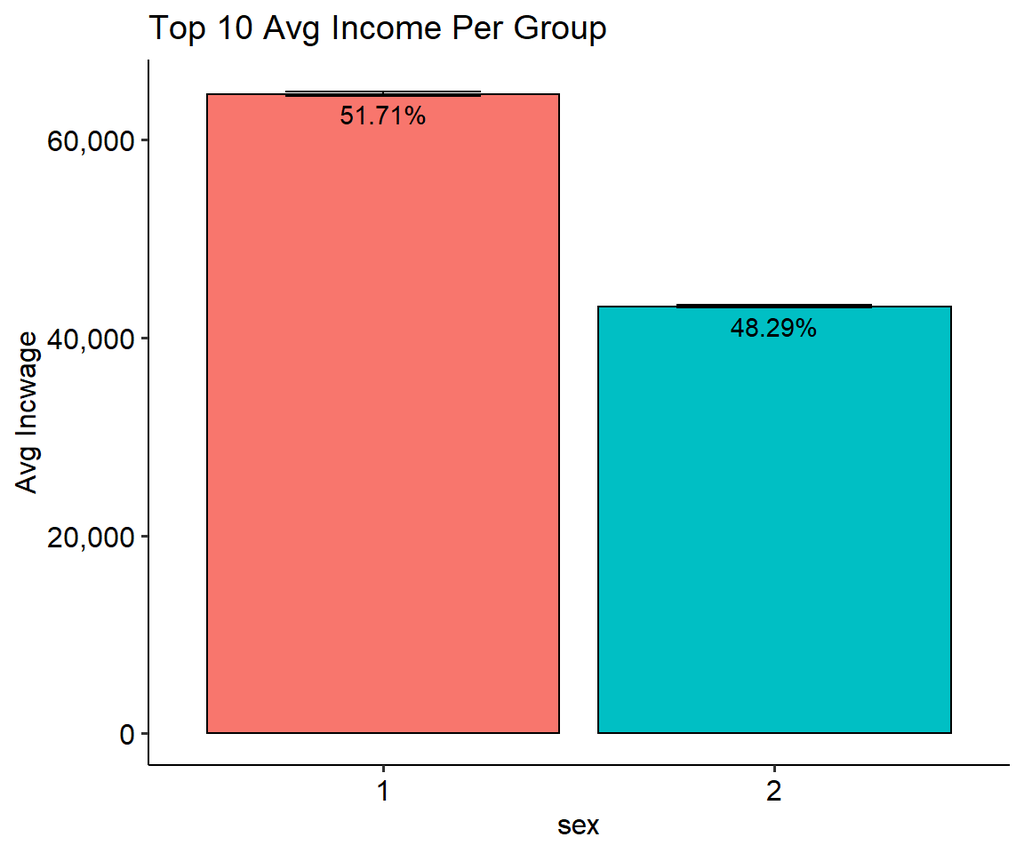

```
## ### marst
## [1] "Number of unique values for marst: 6"
## [1] "Summary on Train/Test rate for group count"
##       Min.    1st Qu.     Median       Mean    3rd Qu.       Max.
## -7.322e-04 -1.730e-04 -5.941e-05  0.000e+00  2.293e-04  7.363e-04
```

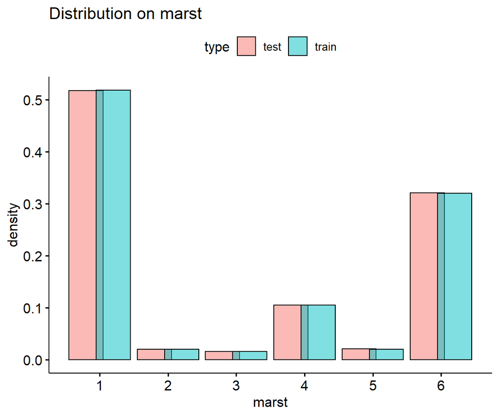

```
## Train Data: check Incwage ~ marst
```

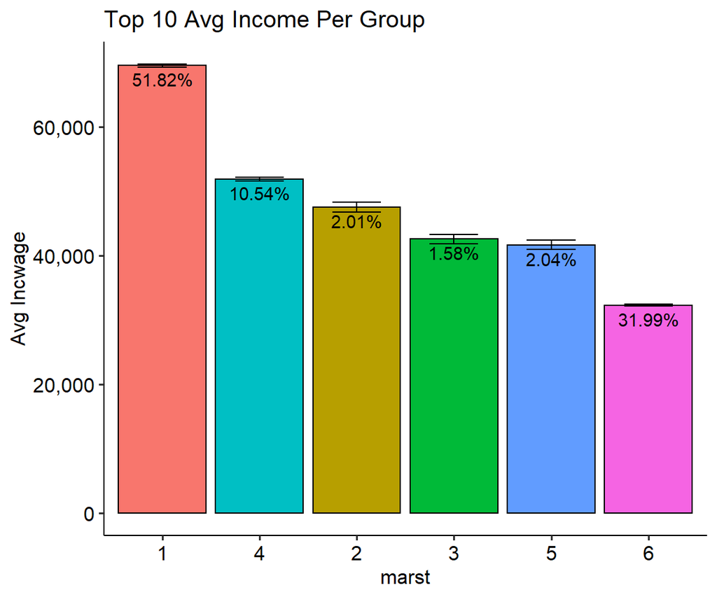

```
## ### race
## [1] "Number of unique values for race: 9"
## [1] "Summary on Train/Test rate for group count"
##       Min.    1st Qu.     Median       Mean    3rd Qu.       Max.
## -9.657e-04  6.868e-06  9.464e-05  0.000e+00  2.068e-04  4.266e-04
```

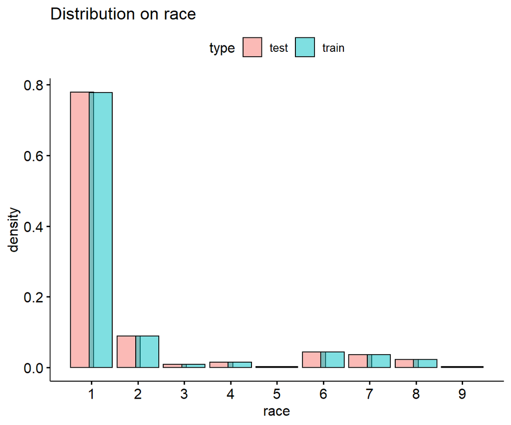

```
## Train Data: check Incwage ~ race
```

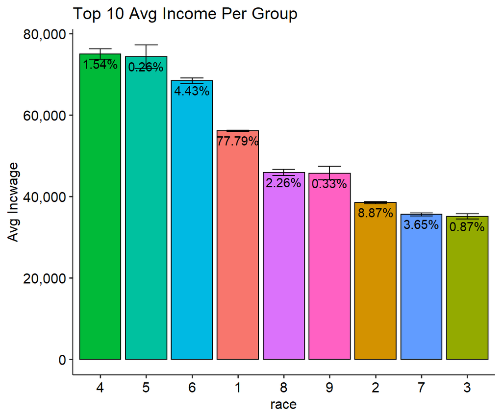

```
## ### bpl
## [1] "Number of unique values for bpl: 123"
## [1] "Summary on Train/Test rate for group count"
##       Min.    1st Qu.     Median       Mean    3rd Qu.       Max.
## -5.344e-04 -3.276e-05  3.937e-06  0.000e+00  5.126e-05  6.504e-04
## Train Data: check Incwage ~ bpl
```

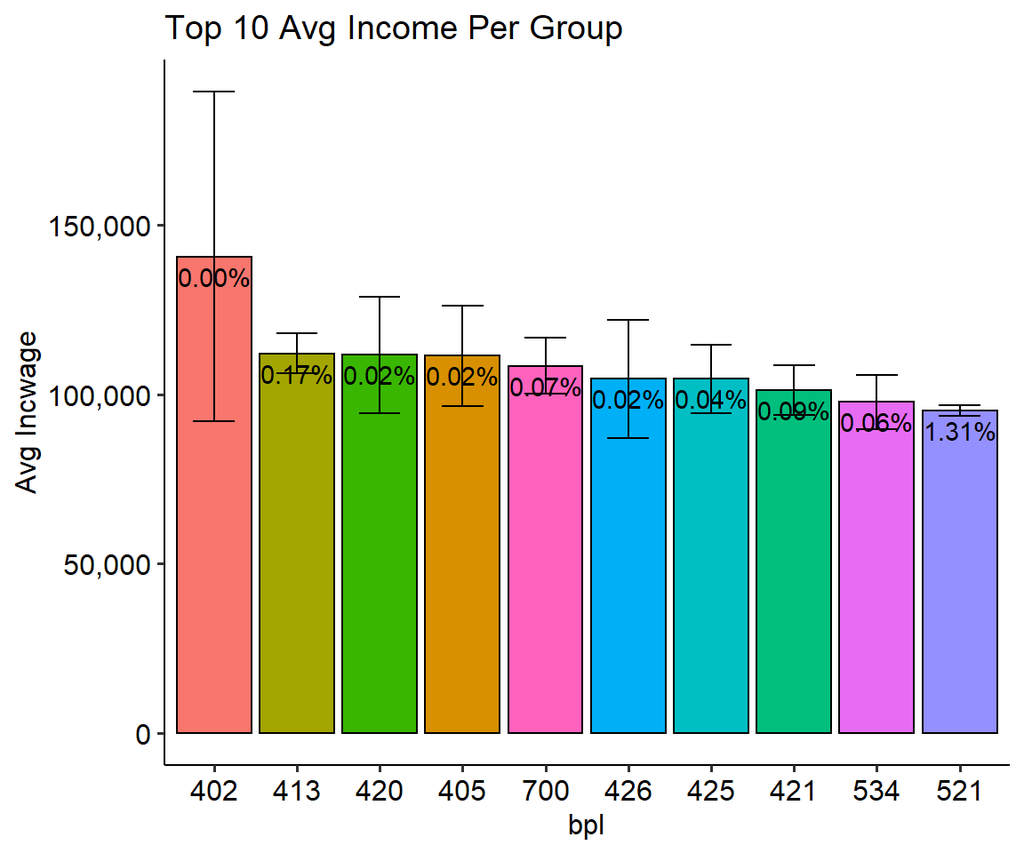

```
## ### language
## [1] "Number of unique values for language: 63"
## [1] "Summary on Train/Test rate for group count"
##       Min.    1st Qu.     Median       Mean    3rd Qu.       Max.
## -1.029e-03 -3.221e-05 -3.140e-06  0.000e+00  3.027e-05  9.699e-04
## Train Data: check Incwage ~ language
```

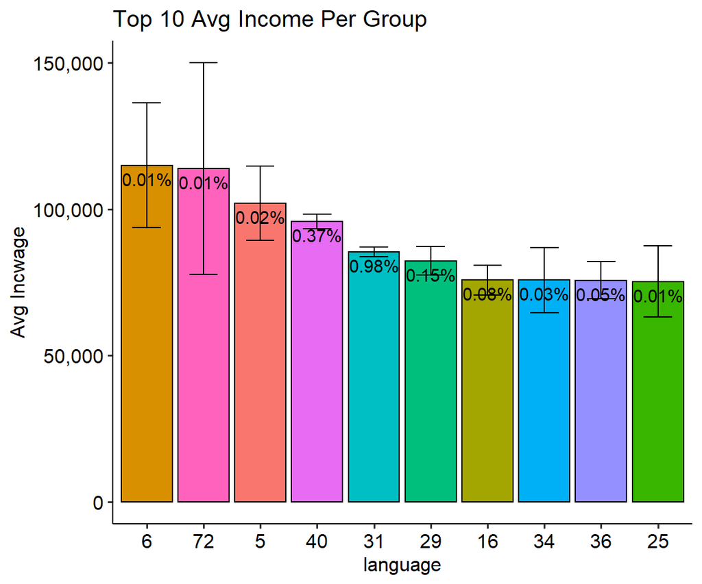

```
## ### educ
## [1] "Number of unique values for educ: 11"
## [1] "Summary on Train/Test rate for group count"
##       Min.    1st Qu.     Median       Mean    3rd Qu.       Max.
## -8.930e-04 -3.214e-04 -9.665e-05  0.000e+00  3.331e-04  1.432e-03
```

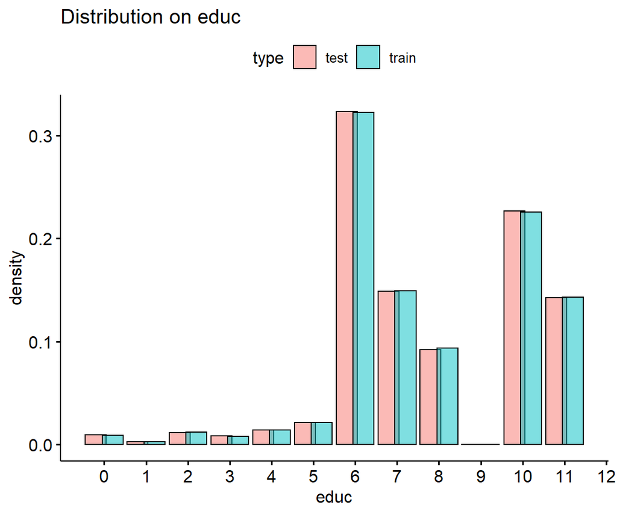

```
## Train Data: check Incwage ~ educ
```

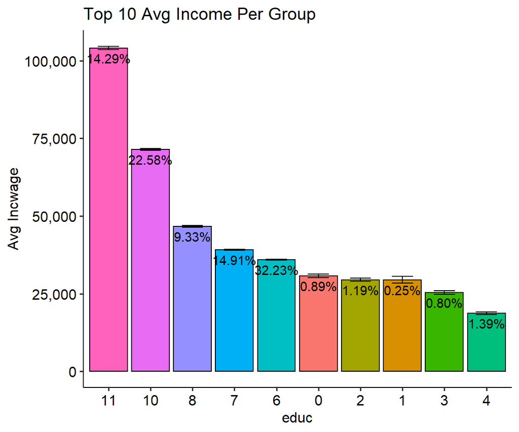

```
## ### degfield
## [1] "Number of unique values for degfield: 38"
## [1] "Summary on Train/Test rate for group count"
##       Min.    1st Qu.     Median       Mean    3rd Qu.       Max.
## -5.648e-04 -6.326e-05  2.764e-06  0.000e+00  7.618e-05  3.728e-04
## Train Data: check Incwage ~ degfield
```

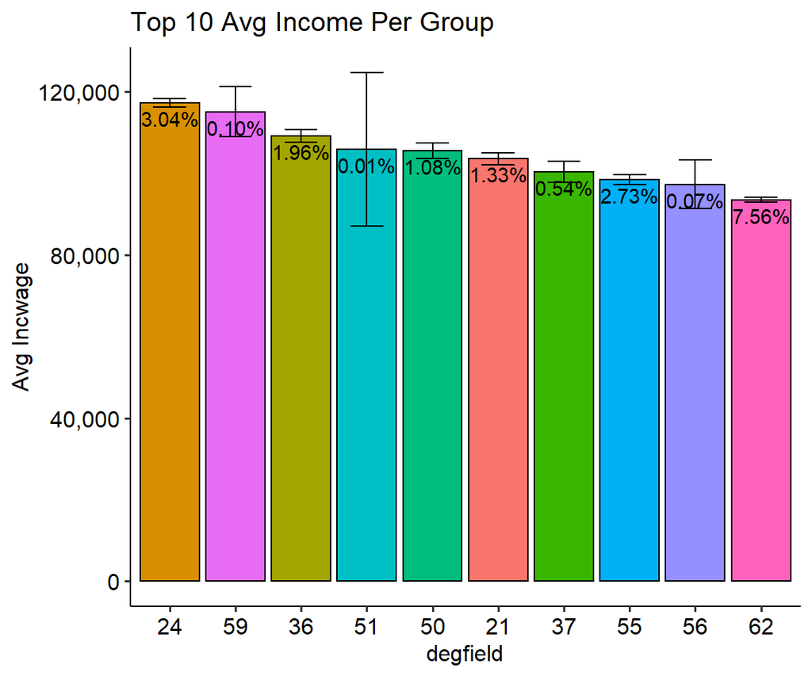

```
## ### vetstat
## [1] "Number of unique values for vetstat: 3"
## [1] "Summary on Train/Test rate for group count"
##       Min.    1st Qu.     Median       Mean    3rd Qu.       Max.
## -3.064e-04 -1.543e-04 -2.121e-06  0.000e+00  1.532e-04  3.086e-04
```

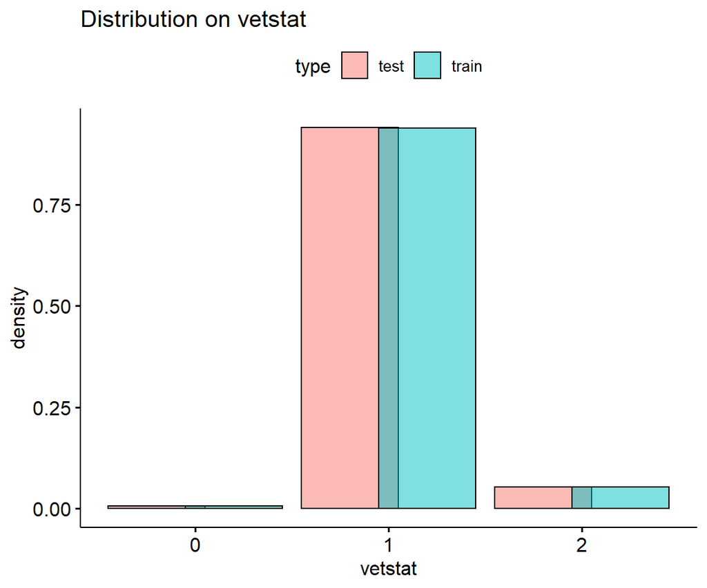

```
## Train Data: check Incwage ~ vetstat
```

[1 more figures not shown]

```r
cat_vars = c("sex", "marst", "race", "bpl", "language", "educ", "degfield", "vetstat")
for(i in cat_vars){
  cat(paste('###', i, "\n"))
  num_unique = dat[,uniqueN(get(i))]
  dat_cat = get_rate_per_group(i)
  print(sprintf("Number of unique values for %s: %i", i, num_unique))
  print("Summary on Train/Test rate for group count")
  print(summary(dat_cat$diff))
  if(num_unique <20){
    p = gghistogram(dat, i, "..density..",
                binwidth = 1, fill="type",
                position=position_dodge(width = 0.8),
                title = sprintf("Distribution on %s", i)) +
      scale_x_continuous(breaks = seq(0,20,1))
    print(p)
  }
  cat(sprintf("Train Data: check Incwage ~ %s", i))
  dat_summary = dat_train[,.(avg = mean(incwage),
                             std = std.error(incwage),
                             count = .N), by=c(i)]
  dat_summary[, `:=`(lower = avg - std, upper = avg + std)]
  dat_summary[, ratio := percent(count/sum(count),accuracy=0.01)]
  setorder(dat_summary, -avg)
  dat_summary = head(dat_summary, 10)
  dat_summary[, (i):= factor(get(i))]

  p4 = ggplot(data=dat_summary, mapping=aes(x=reorder(get(i), -avg),
                                            y=avg,fill=get(i) )) +
    geom_bar(stat="identity", color="black") +
    geom_errorbar(aes(ymin=lower, ymax=upper), width=0.5) +
    labs(title="Top 10 Avg Income Per Group",
         y= "Avg Incwage",
         x=i) +
    scale_y_continuous(labels = number_format(big.mark = ',')) +
    geom_text(aes(label = ratio),  vjust = 1.5) +
    theme_pubr(legend='none')
  print(p4)

  }
```

## 3.2 Numeric Variables

`age`, `uhrswork` (usual hours worked per week; top at 99), and `wkswork1` (weeks worked last year) are treated as continuous variables. I perform Kruskal-Wallis test, a non-parametric one-way ANOVA, to check whether train and test have same means. The null hypothesis is that the distributions are the same in each group.

All have perfect matches on ratios between train and test.

Age, Age square, and hours worked per week are non-linear with log(income)

```
## ### age
```

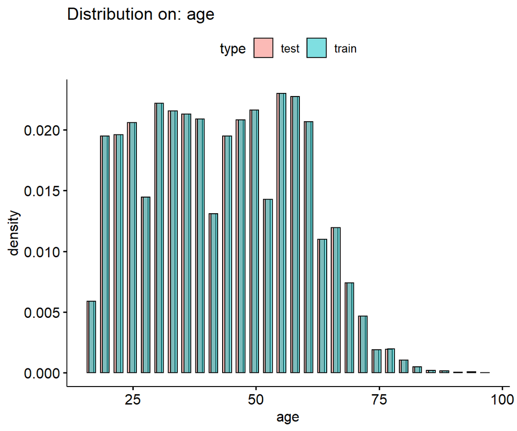

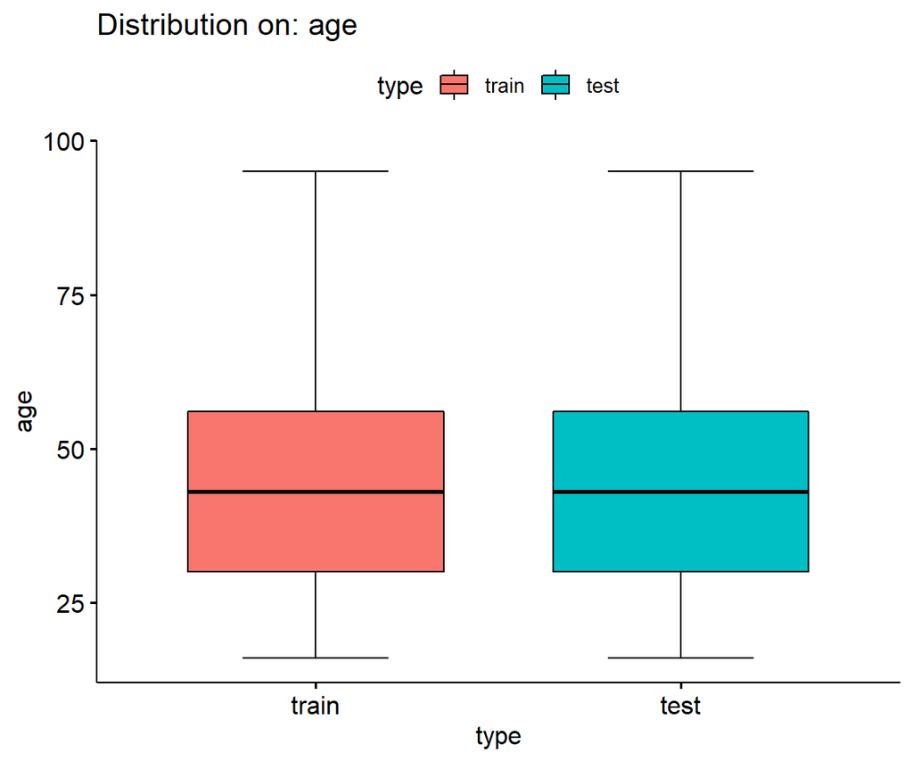

```
##
##  Kruskal-Wallis rank sum test
##
## data:  age by type
## Kruskal-Wallis chi-squared = 3.2766e-05, df = 1, p-value = 0.9954
```

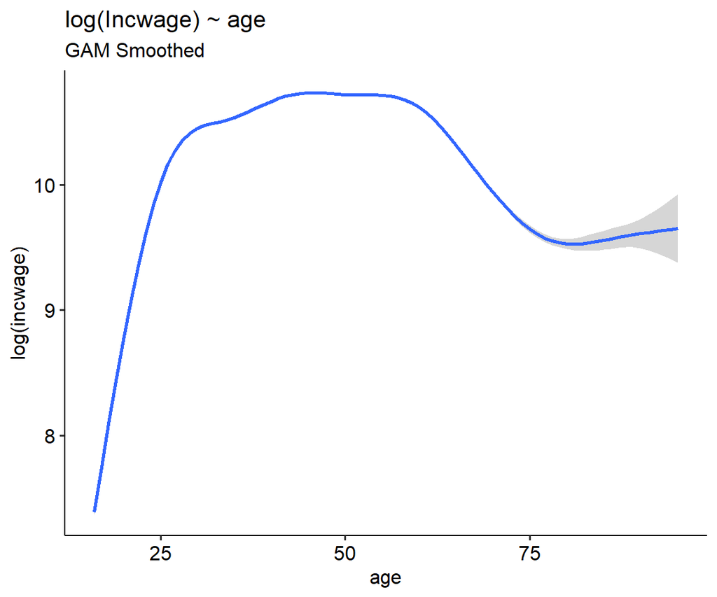

```
## ### uhrswork
```

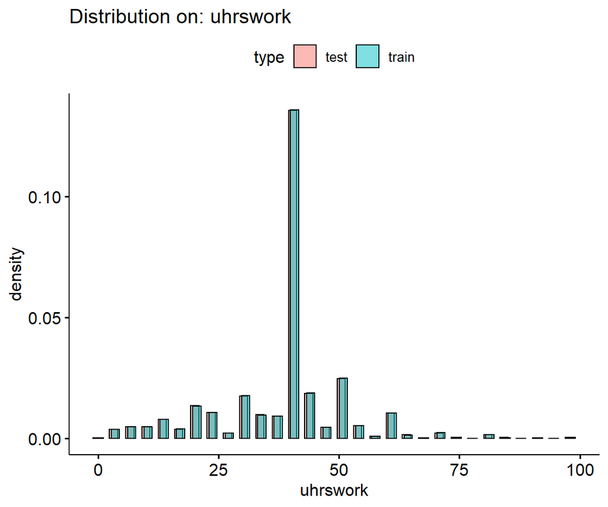

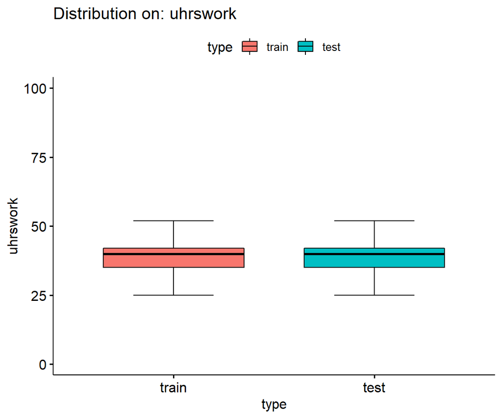

```
##
##  Kruskal-Wallis rank sum test
##
## data:  uhrswork by type
## Kruskal-Wallis chi-squared = 0.67614, df = 1, p-value = 0.4109
```

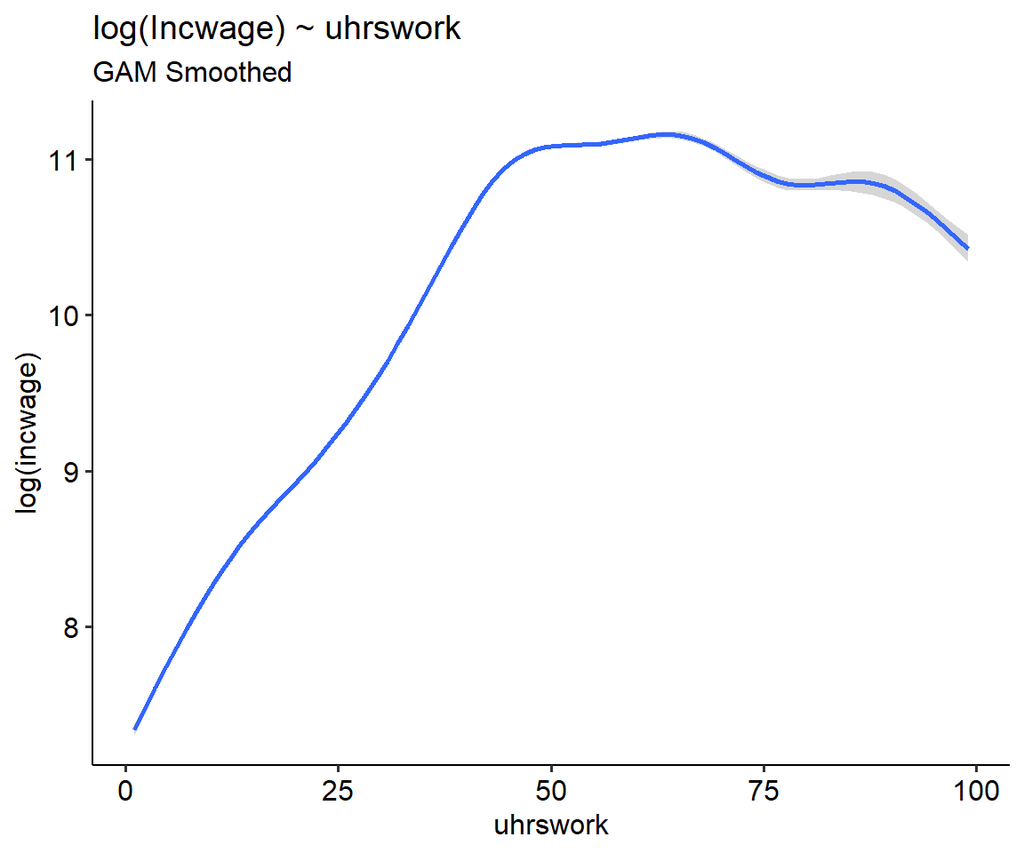

```
## ### wkswork1
```

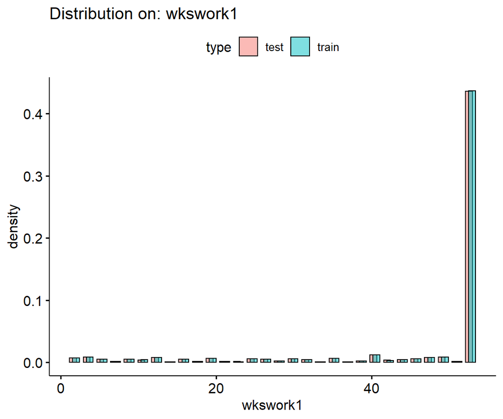

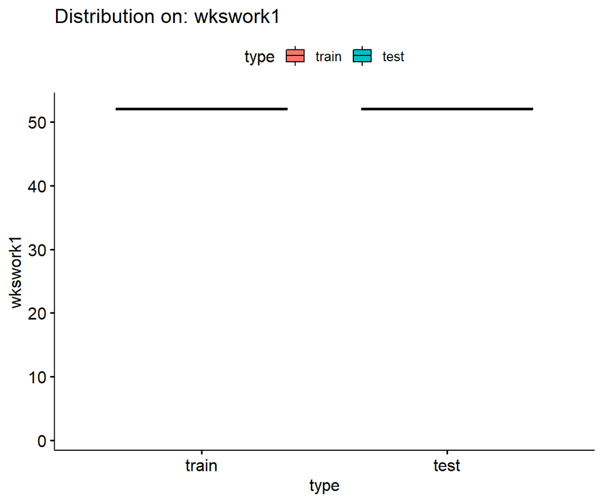

```
##
##  Kruskal-Wallis rank sum test
##
## data:  wkswork1 by type
## Kruskal-Wallis chi-squared = 0.057453, df = 1, p-value = 0.8106
```

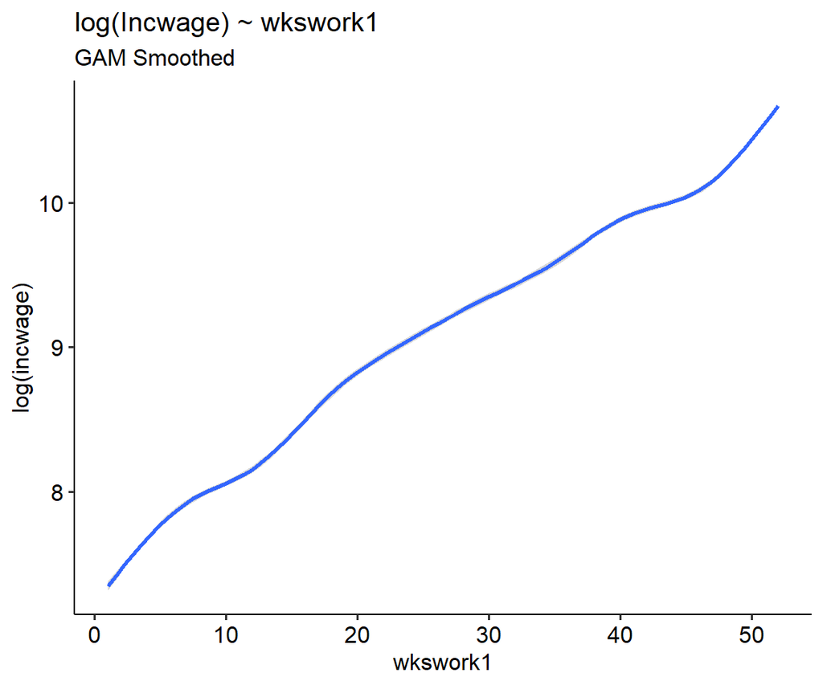

```r
num_vars = c("age", "uhrswork", "wkswork1")

for(i in num_vars) {
  cat(paste('###', i, "\n"))
  p1 = gghistogram(dat, x=i,y="..density..", fill="type",
            position = position_dodge(width = 0.8),
            title=sprintf("Distribution on: %s", i))
  p2 = ggboxplot(data=dat, x="type", y=i,
                 bxp.errorbar=TRUE, outlier.shape = NA,
                 fill="type",
                 title=sprintf("Distribution on: %s", i))
  print(p1)
  print(p2)
  print(kruskal.test(formula = as.formula(paste0(i,"~ type")), data=dat))

  p3 = ggplot(data=dat_train, mapping=aes(x=get(i), y=log(incwage))) +
  geom_smooth(se=TRUE) +
  labs(title=sprintf("log(Incwage) ~ %s",i),
       subtitle="GAM Smoothed",
       x=i) +
  theme_pubr()
  print(p3)
}
```